# scATAC integration

Zack Guo

UCL  
wegmzgu@ucl.ac.uk

August 1, 2026

# Library packages

```r
library(Matrix)
library(Seurat)
library(Signac)
library(dplyr)
library(ggplot2)
library(tidyr)
library(GenomicRanges)
library(GenomeInfoDb)
library(harmony)
library(rtracklayer)
```

# scATAC integration. Parameter and filtering follows the paper where possible with local peak matrix files.

The full scATAC loading workflow is shown below for reproducibility, but this chunk is set to `eval=FALSE`, so it is displayed in the knitted document without being executed. The report loads the saved integrated RDS object below to avoid repeating the expensive calculations.

```r
# This chunk is displayed but not executed during knitting.
# It documents how the raw Cell Ranger ATAC peak matrices were loaded and merged.
setwd("C:/Bioinfo data")

# Define function to read Cell Ranger ATAC peak matrix
load_atac_sample <- function(base_dir, sample_name, sample_label, condition_label) {
  base_dir <- gsub("\\\\", "/", base_dir)

  peak_path <- file.path(base_dir, paste0(sample_name, "_peaks.bed.gz"))
  matrix_path <- file.path(base_dir, paste0(sample_name, "_matrix.mtx.gz"))
  barcode_path <- file.path(base_dir, paste0(sample_name, "_barcodes.tsv.gz"))

  peaks <- read.table(
    gzfile(peak_path),
    sep = "\t",
    header = FALSE,
    stringsAsFactors = FALSE
  )
  colnames(peaks) <- c("chr", "start", "end")

  peak_names <- paste(peaks$chr, peaks$start, peaks$end, sep = "-")

  counts <- readMM(gzfile(matrix_path))
  barcodes <- readLines(gzfile(barcode_path))

  rownames(counts) <- peak_names
  colnames(counts) <- paste(sample_label, barcodes, sep = "_")

  peak_ranges <- makeGRangesFromDataFrame(
    peaks,
    seqnames.field = "chr",
    start.field = "start",
    end.field = "end"
  )
  names(peak_ranges) <- peak_names

  chrom_assay <- CreateChromatinAssay(
    counts = counts,
    ranges = peak_ranges,
    genome = "hg19"
  )

  seu <- CreateSeuratObject(
    counts = chrom_assay,
    assay = "peaks",
    project = sample_label
  )

  seu$sample <- sample_label
  seu$condition <- condition_label

  return(seu)
}

# Load four ATAC samples
base_dir <- "C:/Bioinfo data/Used before/ATAC"

dm1 <- load_atac_sample(base_dir, "GSM4832485_DM-1_hg19", "DM_1", "DM")
dm2 <- load_atac_sample(base_dir, "GSM4832486_DM-2_hg19", "DM_2", "DM")
hm1 <- load_atac_sample(base_dir, "GSM4832487_HM-1_hg19", "HM_1", "HM")
hm2 <- load_atac_sample(base_dir, "GSM4832488_HM-2_hg19", "HM_2", "HM")

# Merge four ATAC samples
atac <- merge(
  dm1,
  y = list(dm2, hm1, hm2)
)

# Load hg19 gene annotation from GRCh37 GTF
gtf_path <- "C:/Bioinfo data/Used before/ATAC/annotation/Homo_sapiens.GRCh37.87.gtf.gz"

gene_annot <- rtracklayer::import(gtf_path)

# Keep gene-level annotation only
gene_annot <- gene_annot[gene_annot$type == "gene"]

# Match chromosome naming style to hg19 peaks
seqlevelsStyle(gene_annot) <- "UCSC"

# Keep standard chromosomes only
gene_annot <- keepStandardChromosomes(
  gene_annot,
  pruning.mode = "coarse"
)

# Set genome information
genome(gene_annot) <- "hg19"

# Add gene annotation to ATAC object
Annotation(atac) <- gene_annot
```

# ATAC dimension reduction and batch correction

This dimension reduction and batch correction workflow is kept as provenance only. It is not executed during knitting because the processed object is loaded from RDS.

```r
# This chunk is displayed but not executed during knitting.
# It documents the TF-IDF, LSI, Harmony, UMAP, neighbor graph, and clustering steps.
DefaultAssay(atac) <- "peaks"

# TF-IDF and LSI follow the standard scATAC workflow. Dimension 1 is usually sequencing depth.
atac <- FindTopFeatures(atac, min.cutoff = 10)
atac <- RunTFIDF(atac)
atac <- RunSVD(atac, n = 30)

# Harmony batch correction using sample as batch variable
atac <- RunHarmony(
  object = atac,
  group.by.vars = "sample",
  reduction = "lsi",
  dims.use = 1:30,
  reduction.save = "harmony",
  project.dim = FALSE
)

# Use dimensions 2 to 30 for downstream analysis because LSI dimension 1 often captures sequencing depth
atac <- RunUMAP(atac, reduction = "harmony", dims = 2:30)
atac <- FindNeighbors(atac, reduction = "harmony", dims = 2:30)
atac <- FindClusters(atac, resolution = 0.6)

DimPlot(atac, reduction = "umap", group.by = "seurat_clusters", label = TRUE)
```

# Gene activity matrix for scRNA-scATAC integration

The gene activity calculation is shown for reproducibility only. It is not executed during knitting because the ACTIVITY assay is already present in the saved RDS object.

```r
# This chunk is displayed but not executed during knitting.
# It documents how peak counts were collapsed into gene activity scores.
# Gene activity score is approximated from the peak count matrix because fragment files are not available
DefaultAssay(atac) <- "peaks"

# Get peak count matrix
peak_counts <- GetAssayData(
  atac,
  assay = "peaks",
  layer = "counts"
)

# Get peak genomic ranges
peak_ranges <- granges(atac[["peaks"]])

# Check that peak ranges and peak count matrix are in the same order
stopifnot(length(peak_ranges) == nrow(peak_counts))

# Manually add peak names because granges() may return unnamed GRanges
names(peak_ranges) <- rownames(peak_counts)

# Get gene annotation
gene_ranges <- Annotation(atac)

# Keep gene-level annotation only
gene_ranges <- gene_ranges[gene_ranges$type == "gene"]

# Get Ensembl gene IDs and remove version suffix if present
gene_ids <- as.character(mcols(gene_ranges)$gene_id)
gene_ids <- sub("\\.\\d+$", "", gene_ids)

# Keep genes with valid Ensembl IDs
keep_genes <- !is.na(gene_ids) & gene_ids != ""
gene_ranges <- gene_ranges[keep_genes]
gene_ids <- gene_ids[keep_genes]

# Extend gene body by 2 kb upstream of TSS
gene_windows <- gene_ranges

plus_strand <- as.character(strand(gene_windows)) == "+"
minus_strand <- as.character(strand(gene_windows)) == "-"
unknown_strand <- as.character(strand(gene_windows)) == "*"

start(gene_windows)[plus_strand] <- pmax(
  1,
  start(gene_windows)[plus_strand] - 2000
)

end(gene_windows)[minus_strand] <- end(gene_windows)[minus_strand] + 2000

start(gene_windows)[unknown_strand] <- pmax(
  1,
  start(gene_windows)[unknown_strand] - 2000
)

# Find peak-gene overlaps
overlaps <- findOverlaps(
  query = gene_windows,
  subject = peak_ranges,
  ignore.strand = TRUE
)

# Build gene-by-peak mapping matrix
unique_gene_ids <- unique(gene_ids)

gene_peak_matrix <- sparseMatrix(
  i = match(gene_ids[queryHits(overlaps)], unique_gene_ids),
  j = subjectHits(overlaps),
  x = 1,
  dims = c(length(unique_gene_ids), length(peak_ranges)),
  dimnames = list(unique_gene_ids, rownames(peak_counts))
)

# Make overlap matrix binary
gene_peak_matrix@x <- rep(1, length(gene_peak_matrix@x))

# Sum peak counts for each gene
gene.activities <- gene_peak_matrix %*% peak_counts

# Keep genes with non-zero activity
gene.activities <- gene.activities[
  Matrix::rowSums(gene.activities) > 0,
]

# Add gene activity matrix as a new assay
atac[["ACTIVITY"]] <- CreateAssayObject(
  counts = gene.activities
)

DefaultAssay(atac) <- "ACTIVITY"

atac <- NormalizeData(atac)

atac <- ScaleData(
  atac,
  features = rownames(atac)
)

# Check result
dim(gene.activities)
head(rownames(gene.activities))
```

# Load annotated scRNA reference saved from the clustering Rmd

This reference-loading step was used for label transfer. It is shown here as provenance only and is not executed during knitting.

```r
# This chunk is displayed but not executed during knitting.
# The transferred labels are loaded from the integrated scATAC RDS below.
rna_reference <- readRDS("C:/Bioinfo data/RDS to skip calc/HM_DM_scRNA_reference_for_ATAC.rds")

DefaultAssay(rna_reference) <- "RNA"
Idents(rna_reference) <- "cell_type"

table(rna_reference$seurat_clusters)
table(rna_reference$cell_type)
```

# Transfer scRNA cell type labels to scATAC cells

The label transfer workflow is displayed but not executed during knitting. The saved RDS object loaded below already contains `atac`, `atac_filtered`, and `predictions`.

```r
# This chunk is displayed but not executed during knitting.
# It documents how scRNA-derived labels were transferred to the scATAC cells.
DefaultAssay(rna_reference) <- "RNA"
DefaultAssay(atac) <- "ACTIVITY"

# Select variable genes from scRNA reference
rna_reference <- FindVariableFeatures(
  rna_reference,
  selection.method = "vst",
  nfeatures = 1500
)

# Use shared variable genes for label transfer
transfer_features <- intersect(
  VariableFeatures(rna_reference),
  rownames(atac[["ACTIVITY"]])
)

length(transfer_features)

# Scale selected transfer genes
rna_reference <- ScaleData(
  rna_reference,
  assay = "RNA",
  features = transfer_features
)

atac <- ScaleData(
  atac,
  assay = "ACTIVITY",
  features = transfer_features
)

# Find transfer anchors
transfer_anchors <- FindTransferAnchors(
  reference = rna_reference,
  query = atac,
  reference.assay = "RNA",
  query.assay = "ACTIVITY",
  reduction = "cca",
  features = transfer_features,
  dims = 1:15
)

# Transfer scRNA cell type labels to scATAC cells
predictions <- TransferData(
  anchorset = transfer_anchors,
  refdata = rna_reference$cell_type,
  weight.reduction = atac[["harmony"]],
  dims = 2:15
)

atac <- AddMetaData(
  atac,
  metadata = predictions
)

# Remove low-confidence predicted cells
atac_filtered <- subset(
  atac,
  subset = prediction.score.max >= 0.3
)

table(atac$predicted.id)
table(atac_filtered$predicted.id)
table(atac_filtered$condition, atac_filtered$predicted.id)

DimPlot(
  atac_filtered,
  reduction = "umap",
  group.by = "predicted.id",
  label = TRUE,
  repel = TRUE
) + NoLegend()
```

# Save integrated scATAC object for downstream analysis

This save step is shown for provenance only. It is not executed during knitting because the integrated RDS object already exists.

```r
# This chunk is displayed but not executed during knitting.
# It documents the object saved for fast report generation and downstream QC.
saveRDS(
  list(
    atac = atac,
    atac_filtered = atac_filtered,
    predictions = predictions
  ),
  "C:/Bioinfo data/RDS to skip calc/HM_DM_scATAC_integrated_with_scRNA_labels.rds"
)
```

# Quality check

The full integrated scATAC object is about 10 GB, so it should not be loaded during knitting. The following chunk is displayed for reproducibility only. Run it manually once from an R session where `atac` and `atac_filtered` are already available, or from a session with enough memory to load the large RDS. It exports the ATAC cluster UMAP, transferred-label UMAP, and lightweight QC results used by the report below.

```r
# This chunk is displayed but not executed during knitting.
# It converts the large integrated scATAC RDS into small QC assets for fast report generation.

integrated_atac_rds <- "C:/Bioinfo data/RDS to skip calc/HM_DM_scATAC_integrated_with_scRNA_labels.rds"
lightweight_qc_rds <- "C:/Bioinfo data/RDS to skip calc/HM_DM_scATAC_lightweight_qc.rds"
asset_dir <- "C:/Bioinfo data/RMD to organize/scATAC_report_assets"
dir.create(asset_dir, showWarnings = FALSE, recursive = TRUE)

integrated_atac <- readRDS(integrated_atac_rds)
atac <- integrated_atac$atac
atac_filtered <- integrated_atac$atac_filtered
predictions <- integrated_atac$predictions

DefaultAssay(atac) <- "ACTIVITY"
DefaultAssay(atac_filtered) <- "ACTIVITY"

meta_atac <- atac@meta.data

umap_atac <- as.data.frame(Embeddings(atac, "umap"))
colnames(umap_atac) <- c("umap_1", "umap_2")
umap_atac$cell <- rownames(umap_atac)
umap_atac$seurat_clusters <- meta_atac[umap_atac$cell, "seurat_clusters"]
umap_atac$sample <- meta_atac[umap_atac$cell, "sample"]
umap_atac$condition <- meta_atac[umap_atac$cell, "condition"]
umap_atac$predicted.id <- meta_atac[umap_atac$cell, "predicted.id"]
umap_atac$prediction.score.max <- meta_atac[umap_atac$cell, "prediction.score.max"]

filtered_cells <- colnames(atac_filtered)
umap_filtered <- umap_atac %>%
  filter(cell %in% filtered_cells)

overall_confidence <- data.frame(
  total_cells = nrow(meta_atac),
  median_prediction_score = median(meta_atac$prediction.score.max, na.rm = TRUE),
  mean_prediction_score = mean(meta_atac$prediction.score.max, na.rm = TRUE),
  cells_above_0.3 = sum(meta_atac$prediction.score.max >= 0.3, na.rm = TRUE),
  pass_rate_above_0.3 = mean(meta_atac$prediction.score.max >= 0.3, na.rm = TRUE)
)

confidence_by_label <- meta_atac %>%
  group_by(predicted.id) %>%
  summarise(
    n_cells = n(),
    median_prediction_score = median(prediction.score.max, na.rm = TRUE),
    mean_prediction_score = mean(prediction.score.max, na.rm = TRUE),
    pass_rate_above_0.3 = mean(prediction.score.max >= 0.3, na.rm = TRUE),
    .groups = "drop"
  ) %>%
  arrange(desc(n_cells))

cluster_label_counts <- as.data.frame(
  table(atac$seurat_clusters, atac$predicted.id)
)
colnames(cluster_label_counts) <- c("atac_cluster", "predicted_label", "n_cells")

cluster_label_props <- cluster_label_counts %>%
  group_by(atac_cluster) %>%
  mutate(
    cluster_total = sum(n_cells),
    fraction = n_cells / cluster_total
  ) %>%
  ungroup()

cluster_purity <- cluster_label_props %>%
  group_by(atac_cluster) %>%
  slice_max(fraction, n = 1, with_ties = FALSE) %>%
  ungroup() %>%
  arrange(as.numeric(as.character(atac_cluster)))

lineage_markers <- c("FGG", "ACSM3", "APOC1", "CYP3A5", "TFF1", "KRT7", "EPCAM")

gene_map <- as.data.frame(Annotation(atac[["peaks"]])) %>%
  dplyr::select(gene_id, gene_name) %>%
  mutate(gene_id = sub("\\.\\d+$", "", gene_id)) %>%
  distinct(gene_name, .keep_all = TRUE)

marker_features <- gene_map %>%
  filter(gene_name %in% lineage_markers) %>%
  filter(gene_id %in% rownames(atac_filtered[["ACTIVITY"]]))

features_use <- marker_features$gene_id
names(features_use) <- marker_features$gene_name

marker_dot_data <- DotPlot(
  atac_filtered,
  features = unname(features_use),
  group.by = "predicted.id"
)$data

marker_dot_data$gene_symbol <- names(features_use)[
  match(marker_dot_data$features.plot, unname(features_use))
]

ggsave(
  filename = file.path(asset_dir, "integrated_atac_umap_true.png"),
  plot = DimPlot(
    atac,
    reduction = "umap",
    group.by = "seurat_clusters",
    label = TRUE,
    repel = TRUE
  ) + NoLegend(),
  width = 7,
  height = 5,
  dpi = 300
)

ggsave(
  filename = file.path(asset_dir, "transferred_label_umap_true.png"),
  plot = DimPlot(
    atac_filtered,
    reduction = "umap",
    group.by = "predicted.id",
    label = TRUE,
    repel = TRUE
  ) + NoLegend(),
  width = 7,
  height = 5,
  dpi = 300
)

saveRDS(
  list(
    umap_atac = umap_atac,
    umap_filtered = umap_filtered,
    overall_confidence = overall_confidence,
    confidence_by_label = confidence_by_label,
    cluster_purity = cluster_purity,
    cluster_label_props = cluster_label_props,
    marker_dot_data = marker_dot_data
  ),
  lightweight_qc_rds
)
```

```r
# Load lightweight tabular QC results that were exported from the previous analysis run.
asset_dir <- "C:/Bioinfo data/RMD to organize/scATAC_report_assets"

confidence_by_label <- read.csv(
  file.path(asset_dir, "confidence_by_label.csv"),
  stringsAsFactors = FALSE
)

cluster_purity <- read.csv(
  file.path(asset_dir, "cluster_purity.csv"),
  stringsAsFactors = FALSE
)
```

# Unsupervised ATAC cluster UMAP

This UMAP shows the scATAC embedding after LSI-based dimensional reduction and Harmony batch correction. The colours represent unsupervised ATAC clusters, not transferred cell-type labels.

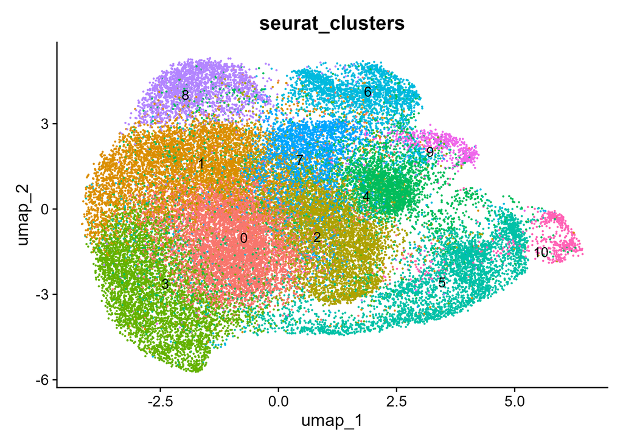

```r
atac_cluster_umap_png <- file.path(asset_dir, "integrated_atac_umap_true.png")

knitr::include_graphics(atac_cluster_umap_png)
```

# Transferred label UMAP

This UMAP shows the same ATAC embedding after filtering low-confidence transferred labels (`prediction.score.max >= 0.3`) and colouring cells by the scRNA-derived label.

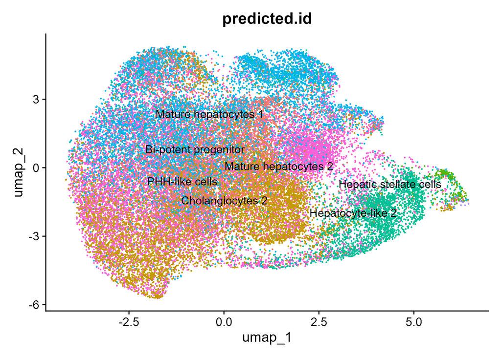

```r
transferred_umap_png <- file.path(asset_dir, "transferred_label_umap_true.png")

knitr::include_graphics(transferred_umap_png)
```

# Label transfer confidence

The table below summarises label transfer confidence by transferred cell type. Most median prediction scores are moderate rather than high, and `Mature hepatocytes 2` has the weakest support among the listed labels.

```r
confidence_by_label
```

| predicted.id | n_cells | median_prediction_score | mean_prediction_score | pass_rate_above_0.3 |
| --- | --- | --- | --- | --- |
| PHH-like cells | 9964 | 0.4915073 | 0.5207249 | 0.9542352 |
| Mature hepatocytes 1 | 9354 | 0.4471699 | 0.4722064 | 0.9412016 |
| Cholangiocytes 2 | 8045 | 0.5016411 | 0.5211105 | 0.9516470 |
| Bi-potent progenitor | 5402 | 0.4047717 | 0.4217869 | 0.9137357 |
| Hepatocyte-like 2 | 3613 | 0.5694117 | 0.5821886 | 0.9507335 |
| Mature hepatocytes 2 | 329 | 0.3515248 | 0.3712631 | 0.7446809 |
| Hepatic stellate cells | 233 | 0.4564991 | 0.4700540 | 0.8884120 |

# Cluster-label consistency

This check asks whether each unsupervised ATAC cluster is dominated by one transferred scRNA label. Good label transfer would usually show high cluster purity for most clusters.

```r
cluster_purity
```

| atac_cluster | predicted_label | n_cells | cluster_total | fraction |
| --- | --- | --- | --- | --- |
| 0 | Bi-potent progenitor | 1653 | 6214 | 0.2660122 |
| 1 | Mature hepatocytes 1 | 2779 | 5775 | 0.4812121 |
| 2 | Cholangiocytes 2 | 2700 | 4631 | 0.5830274 |
| 3 | Cholangiocytes 2 | 2198 | 4592 | 0.4786585 |
| 4 | PHH-like cells | 3241 | 3956 | 0.8192619 |
| 5 | Hepatocyte-like 2 | 2454 | 3512 | 0.6987472 |
| 6 | Mature hepatocytes 1 | 1907 | 2655 | 0.7182674 |
| 7 | Bi-potent progenitor | 1029 | 2278 | 0.4517120 |
| 8 | Mature hepatocytes 1 | 1096 | 2265 | 0.4838852 |
| 9 | Mature hepatocytes 1 | 245 | 555 | 0.4414414 |

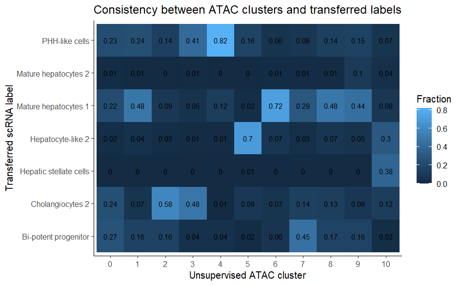

```r
knitr::include_graphics(
  file.path(asset_dir, "cluster_label_heatmap.png")
)
```

# Marker gene activity

Marker gene activity provides an independent sanity check for the transferred labels. A reliable annotation should show clearer cell-type-specific marker activity across the transferred groups.

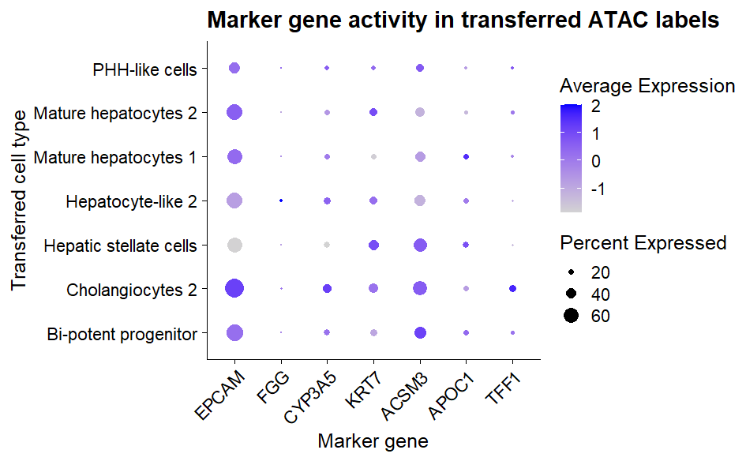

```r
knitr::include_graphics(
  file.path(asset_dir, "marker_gene_activity_dotplot.png")
)
```

# Interpretation

The unsupervised ATAC cluster UMAP shows that the four HM/DM scATAC samples can be embedded and clustered after LSI and Harmony correction. However, the transferred scRNA labels should be interpreted cautiously. The prediction scores are mostly moderate rather than high, several ATAC clusters do not have a single dominant transferred label, and the marker gene activity plot does not show a clean cell-type-specific pattern across all labels.

Overall, the scRNA-to-scATAC label transfer is useful as an exploratory annotation, but it is not strong enough to support high-confidence cell-type-specific interpretation of the scATAC data. This suggests that this scATAC reference should be treated carefully in downstream cell-of-origin analysis.